# Reproducible analysis : Project 1

Joachim

28/02/2021

## Loading and preprocessing the data

Show any code that is needed to

1. Load the data (i.e. read.csv()
2. Process/transform the data (if necessary) into a format suitable for your analysis

```r
library(readr)
URL <- "https://d396qusza40orc.cloudfront.net/repdata%2Fdata%2Factivity.zip"
download.file(URL, "data.zip")
unzip("data.zip")
activity <- read_csv("activity.csv")
```

## What is mean total number of steps taken per day?

For this part of the assignment, you can ignore the missing values in the dataset.

1. Calculate the total number of steps taken per day
2. If you do not understand the difference between a histogram and a barplot, research the difference between them. Make a histogram of the total number of steps taken each day
3. Calculate and report the mean and median of the total number of steps taken per day

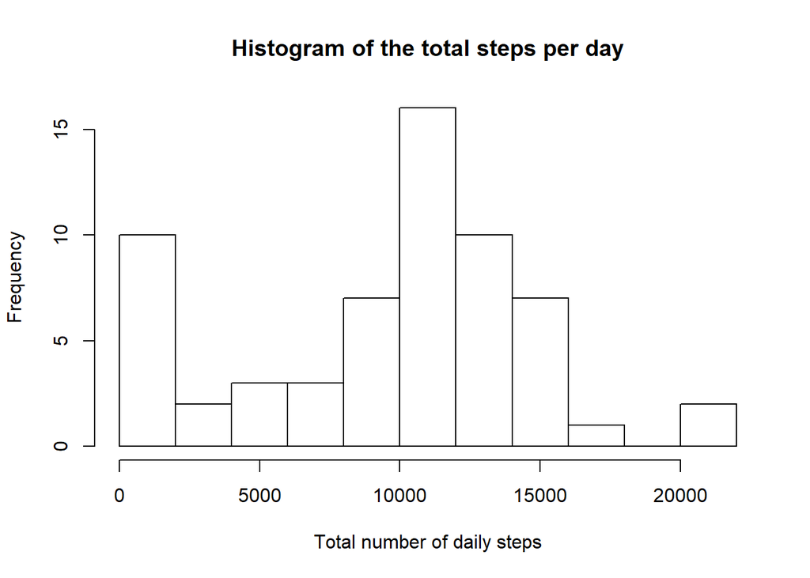

```r
library(dplyr)

#first question
daysteps <- activity %>%
        group_by(date) %>%
        summarize(daysteps = sum(steps, na.rm= T))

#second question
hist(daysteps$daysteps, breaks = 10,
     xlab = "Total number of daily steps", main = "Histogram of the total steps per day")
```

```r
#third question
meanstep <- round(mean(daysteps$daysteps, na.rm = T), digits = 2)
medianstep <-  median(daysteps$daysteps, na.rm = T)
```

The mean of the total number of steps taken per day is 9354.23, the median is 10395.

## What is the average daily activity pattern?

1. Make a time series plot (i.e. type = “l”) of the 5-minute interval (x-axis) and the average number of steps taken, averaged across all days (y-axis)
2. Which 5-minute interval, on average across all the days in the dataset, contains the maximum number of steps?

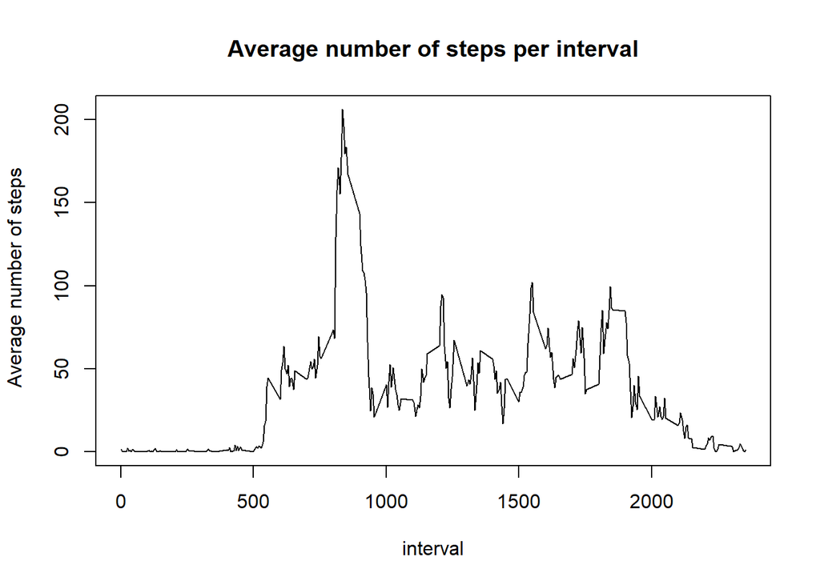

```r
stepinterval <- activity %>% group_by(interval) %>% summarize(average_step = mean(steps, na.rm = T))

#first question
with(stepinterval,        plot(interval, average_step,  type = "l", ylab = " Average number of steps", main  = "Average number of steps per interval"))
```

```r
#second question
maxinterval <- stepinterval[[which.max(stepinterval$average_step),"interval"]]
```

## Imputing missing values

Note that there are a number of days/intervals where there are missing values (coded as NA). The presence of missing days may introduce bias into some calculations or summaries of the data.

[output not shown]

```r
# first question
NA_total <-  sum(!complete.cases(activity))
```

There are 2304missing values in the dataset. In the “activity2” dataset, the missing values have been replaced by the interval’s average number of steps through all days.

```r
# second and third question
activity2 <-  activity %>%
        group_by(interval) %>%
        mutate(
                steps = case_when(
                        is.na(steps) ~ mean(steps, na.rm =T),
                        TRUE ~ steps
                )
        )


sum(!complete.cases(activity2))
```

```
## [1] 0
```

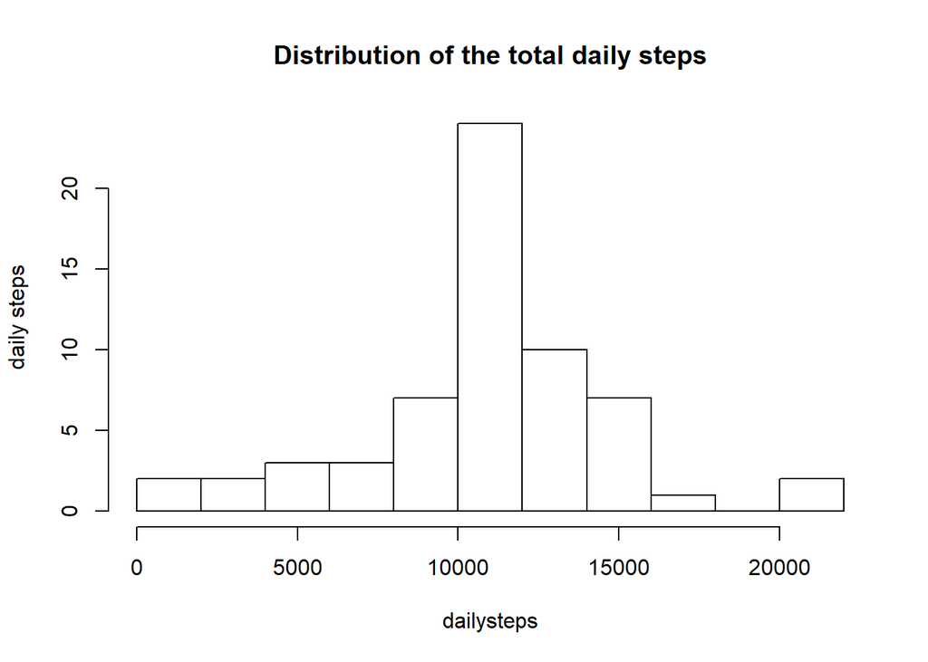

```r
# the number of uncomplete row in the new data frame is equal to zero


#fourth question
dailysteps <- activity2 %>%
        group_by(date) %>%
        summarize(dailysteps = sum(steps))
with(dailysteps, hist(dailysteps, breaks = 10, ylab = "daily steps", main = "Distribution of the total daily steps"))
```

We see in the new histogram that the total daily number of steps have increased. For instance, in the first histogram, there were many days with 0 step because the missing values where simply excluded while, in this one, there are few days with 0 step. The new histogram is much more symetric and is closer to a normal distribution.

## Are there differences in activity patterns between weekdays and weekends?

For this part the weekdays() function may be of some help here. Use the dataset with the filled-in missing values for this part.

1. Create a new factor variable in the dataset with two levels – “weekday” and “weekend” indicating whether a given date is a weekday or weekend day.
2. Make a panel plot containing a time series plot (i.e. type = “l”) of the 5-minute interval (x-axis) and the average number of steps taken, averaged across all weekday days or weekend days (y-axis). See the README file in the GitHub repository to see an example of what this plot should look like using simulated data.

```r
#setting the language in English
Sys.setlocale("LC_TIME", "English")
```

```
## [1] "English_United States.1252"
```

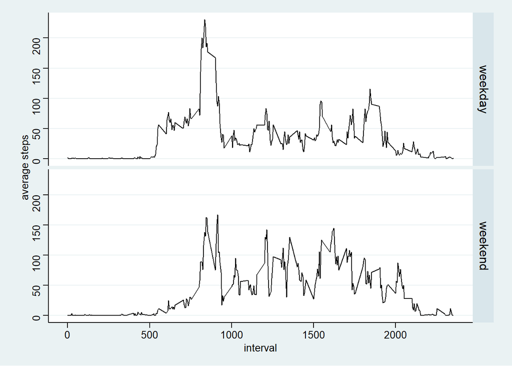

```r
#first question
activity2<- activity2 %>% mutate(
        weekday = weekdays(date),
        weekday = factor(
                        case_when(
                                weekday %in% c("Saturday", "Sunday")  ~ "weekend",
                                TRUE ~ "weekday"
                        )
                )
)

#second question

library(ggplot2)
library(ggthemes)
interval_steps <- activity2 %>%
        group_by(interval, weekday) %>%
        summarize(mean_step = mean(steps))

interval_steps %>%
        ggplot(aes(y= mean_step, x = interval )) +
                geom_line() +
                facet_grid(rows = vars(weekday))+
                labs(y = "average steps") +
                theme_stata()
```